# Exploratory data analysis with Yeast RNAseq data

## Sniff Test of Data

In Adrienne’s presentation earlier this week, she showed us a sniff test of her data. She used a pairwise comparison of the Salmon Transcripts Per Million (TPM) to understand how well her replicates replicated each other. We will do the same thing.

Remember the `gather-counts.py` code we gave you? We tweaked that script a bit to gather the TPM data (transcripts per million) in order to make a plot of this data. We ran this with `python2 gather-tpm.py`, which output a bunch of `.tmp` files. We will now work with these.

We will use a ggplot2-esque package to perform “sniff tests” like Adrienne spoke about. As a first pass, we will make pairwise comparison plots to see how well the replicates actually replicate each other.

```r
head(tpm_df)
```

```
##         ERR458493.fastq.gz.quant ERR458494.fastq.gz.quant
## YAL001C                        5                        3
## YAL002W                        4                        4
## YAL003W                      647                      633
## YAL005C                      278                      292
## YAL007C                       79                       88
## YAL008W                       38                       33
##         ERR458495.fastq.gz.quant ERR458500.fastq.gz.quant
## YAL001C                        2                        5
## YAL002W                        3                        4
## YAL003W                      616                      375
## YAL005C                      269                      119
## YAL007C                       72                       97
## YAL008W                       44                       41
##         ERR458501.fastq.gz.quant ERR458502.fastq.gz.quant
## YAL001C                        5                        5
## YAL002W                        5                        4
## YAL003W                      375                      352
## YAL005C                      117                      120
## YAL007C                       88                      106
## YAL008W                       51                       55
```

The first pairwise plot we make displays the wildtype samples. These are highly correlated, and thus replicate eachother quite well.

```r
    pairwise_wt
```

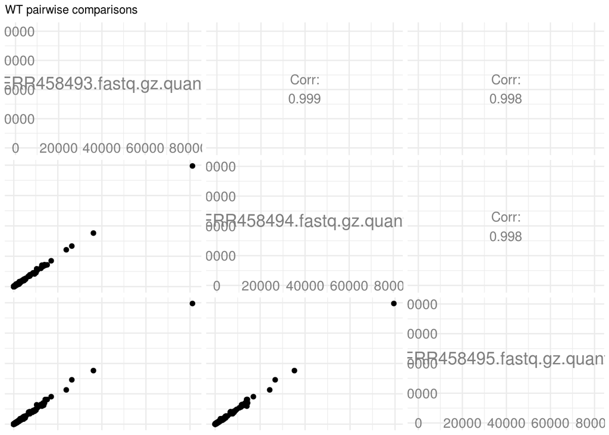

We can do the same thing for the mutant samples. These are highly correlated as well, and also replicate eachother well.

```r
      pairwise_mut
```

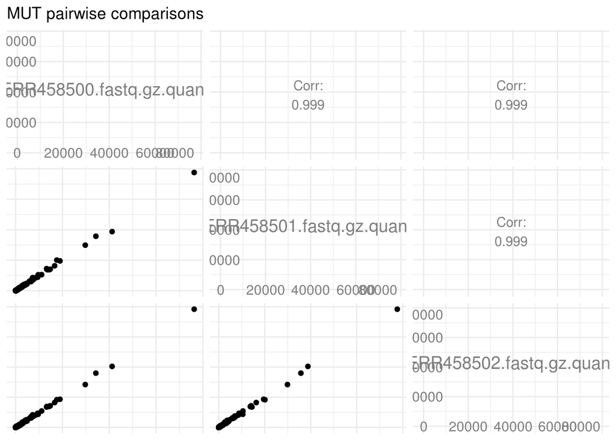

These plots show us that our data look good – it is valid to continue on and do differential expression with these data, because the replicates are true biological replicates.

Questions: 1. What species do you work with? Do you expect your biological replicates to be this similar? 2. Would you expect laboratory or environmental samples to be more variable? 3. What would alarming data look like? 4. How is TPM data different than raw counts? How is it different from edgeR or DeSEQ2 corrected results?

## Differential Expression

Since our data appears to be of high quality, let’s perform differential expression with edgeR like we did before. We need to read in the proper count data, because edgeR expects raw counts, not counts that have been corrected in anyway. We will allow edgeR to perform correction for library size, and then estimate [dispersion](https://doi.org/10.1371/journal.pone.0081415).

This will give us a DGE object. We can look at the DGE object and see some of the magic of edgeR.

```r
    head(dge$samples)
```

```
##                          group lib.size norm.factors
## ERR458493.fastq.gz.quant    wt   963028    0.8632726
## ERR458494.fastq.gz.quant    wt   955258    0.8649983
## ERR458495.fastq.gz.quant    wt   950704    0.8644693
## ERR458500.fastq.gz.quant   mut  1620091    1.1574783
## ERR458501.fastq.gz.quant   mut  1616974    1.1568370
## ERR458502.fastq.gz.quant   mut  1611768    1.1569170
```

```r
    head(dge$counts)
```

```
##          Samples
## Tags      ERR458493.fastq.gz.quant ERR458494.fastq.gz.quant
##   YAL001C                       61                       39
##   YAL002W                       44                       40
##   YAL003W                     1009                      965
##   YAL005C                     1864                     1916
##   YAL007C                       86                       93
##   YAL008W                       40                       34
##          Samples
## Tags      ERR458495.fastq.gz.quant ERR458500.fastq.gz.quant
##   YAL001C                       27                      126
##   YAL002W                       32                      106
##   YAL003W                      948                     1103
##   YAL005C                     1775                     1481
##   YAL007C                       77                      219
##   YAL008W                       46                       87
##          Samples
## Tags      ERR458501.fastq.gz.quant ERR458502.fastq.gz.quant
##   YAL001C                      129                      121
##   YAL002W                      117                       96
##   YAL003W                     1105                     1033
##   YAL005C                     1454                     1489
##   YAL007C                      198                      240
##   YAL008W                      107                      116
```

Lastly, we perform differential expression

## Data Visualization

Differential expression outputs a large file, which may leave you thinking…what next??

### MDS Plot

We can make an MDS plot to understand how our samples relate to one another. From the edgeR manual: “a multi-dimensional scaling plot of the RNA samples in which distances correspond to leading log-fold-changes between each pair of RNA samples. The leading log-fold-change is the average (root-mean-square) of the largest absolute log-foldchanges between each pair of samples. This plot can be viewed as a type of unsupervised clustering.” Our MUT samples cluster more closely to each other than to the WT samples. Does this agree with the sniff tests from pairwise comparisons we performed above?

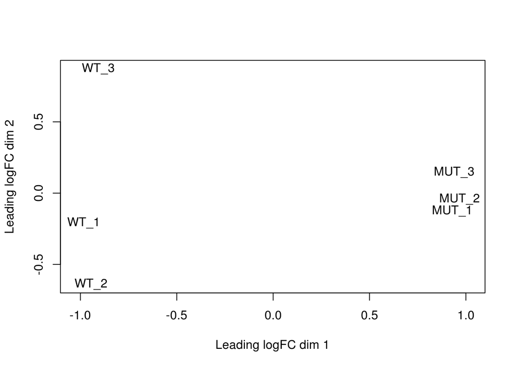

```r
  plotMDS(dge, labels=labels)
```

### MA Plot

We can also make an MA plot. From wikipedia: “an MA plot is an application of a Bland–Altman plot for visual representation of genomic data. The plot visualises the differences between measurements taken in two samples, by transforming the data onto M (log ratio) and A (mean average) scales, then plotting these values.”"

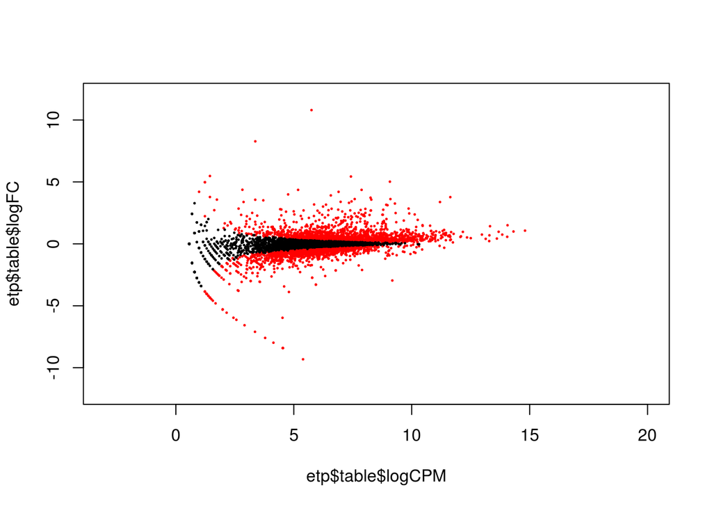

```r
    etp$table$logFC = -etp$table$logFC # because our comparison is mut vs. wt, let's flip the tags for our plot
    plot(etp$table$logCPM, etp$table$logFC, xlim=c(-3, 20), ylim=c(-12, 12), pch=20, cex=.3,
        col = ifelse( etp$table$FDR < .2, "red", "black" ) )
```

### Histogram We can also make a histogram of the corrected p value (FDR). This shows that almost an equal number of differentially expressed and non-differentially expressed genes.

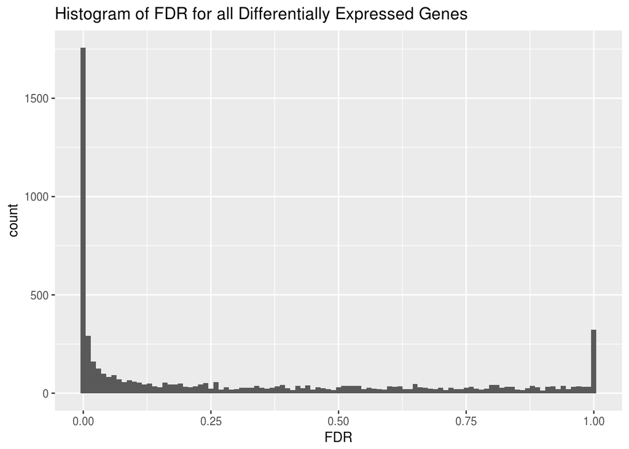

```r
library(ggplot2)
ggplot(etp$table, aes(FDR)) + geom_histogram(binwidth = .01) + ggtitle("Histogram of FDR for all Differentially Expressed Genes")
```

### Heatmaps

Heatmaps are also a very popular way to visualize data. Let’s make a heat map of the 75 most variable genes!

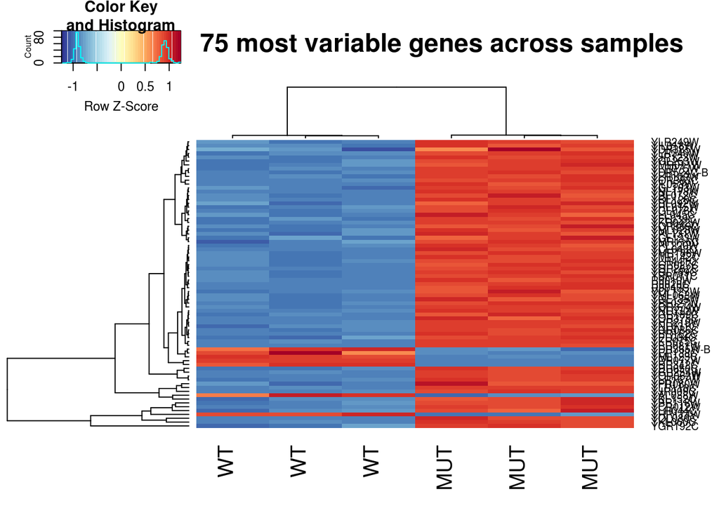

```r
# Load library for heatmap
    library(gplots)
    heatmap.2(highly_variable_norm_counts, col=rev(morecols(50)), trace="none",
              main="Top 75 most variable genes across samples", scale="row",
              labCol = c("WT", "WT", "WT", "MUT", "MUT", "MUT"))
```

Let’s do the same thing again, but this time we will plot the top 75 least variable genes. Even though we did cpm normalization, a lot of these genes are still very lowly expressed.

This is important to keep in mind when interpretting what this heatmap means.

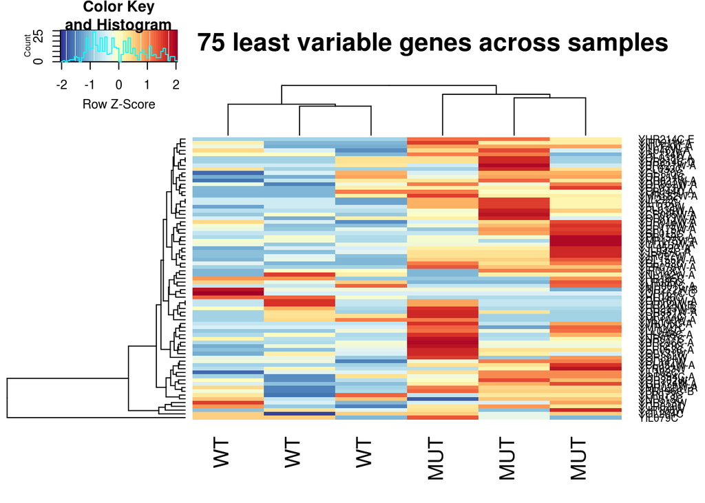

```r
# Load library for heatmap
    library(gplots)
    heatmap.2(not_variable_norm_counts, col=rev(morecols(50)), trace="none",
              main="Top 75 least variable genes across samples", scale="row",
              labCol = c("WT", "WT", "WT", "MUT", "MUT", "MUT"))
```